# tidy missing data

Eleanor Zhang

Load packaged at need.

```r
library(tidyverse)
library(naniar) # deal with missing value
```

# 1 Search and replace missing values

Missing data are not always coded as NA! The objective here is to:

- Look for hidden missing values
- Replace missing values with NA
- Check assumptions on missingness

Some possible incorrectly coded missing values: “missing”, “Not Available”, “N/A”… These need to be recoded into “NA”.

Let’s create a chaotic case

```r
bad.df <- tibble(score = c(3, -99, 4, -99, 7, 10, 12, 16, 9),
            grade = c("N/A", "E", "missing", "na", "n/a", "NULL", ".", "NULL", "N/a"),
            place = c(-99, 97, 95, 92, -98, "missing", 88, ".", 86))
```

## 1.1 search for missing values

Seach for specific entry and it returns number of occurence in each variable

```r
bad.df %>% miss_scan_count(search = list("N/A"))
```

```
## # A tibble: 3 x 2
##   Variable     n
##   <chr>    <int>
## 1 score        0
## 2 grade        1
## 3 place        0
```

```r
# it can take multiple entries to search
bad.df %>% miss_scan_count(search = list("N/A", "N/a"))
```

```
## # A tibble: 3 x 2
##   Variable     n
##   <chr>    <int>
## 1 score        0
## 2 grade        2
## 3 place        0
```

## 1.2 Replace targeted entries with NA

```r
# replace specific entries in grade with NA
bad.df %>% replace_with_na(replace = list(grade = c("N/A", "N/a")))
```

```
## # A tibble: 9 x 3
##   score grade   place
##   <dbl> <chr>   <chr>
## 1     3 <NA>    -99
## 2   -99 E       97
## 3     4 missing 95
## 4   -99 na      92
## 5     7 n/a     -98
## 6    10 NULL    missing
## 7    12 .       88
## 8    16 NULL    .
## 9     9 <NA>    86
```

To reduce code repetition and provide other options to replace with NA using scope of variants:

- `replace_with_na_all()`: all variables
- `replace_with_na_at()`: a subset of variables
- `replace_with_na_if()`: replace a subset of variables that satisfied some condition

Replace all entries of -99 with NA

```r
bad.df %>% replace_with_na_all(condition = ~.x == -99)
```

```
## # A tibble: 9 x 3
##   score grade   place
##   <dbl> <chr>   <chr>
## 1     3 N/A     <NA>
## 2    NA E       97
## 3     4 missing 95
## 4    NA na      92
## 5     7 n/a     -98
## 6    10 NULL    missing
## 7    12 .       88
## 8    16 NULL    .
## 9     9 N/a     86
```

Replace some entries with NA

```r
bad.df %>% replace_with_na_all(condition = ~.x %in% c("N/A", "missing", "na"))
```

```
## # A tibble: 9 x 3
##   score grade place
##   <dbl> <chr> <chr>
## 1     3 <NA>  -99
## 2   -99 E     97
## 3     4 <NA>  95
## 4   -99 <NA>  92
## 5     7 n/a   -98
## 6    10 NULL  <NA>
## 7    12 .     88
## 8    16 NULL  .
## 9     9 N/a   86
```

Replace in a subset of variables

```r
replace_with_na_at(bad.df,
                   .vars = c("score", "grade"),
                   ~.x %in% c("N/A", "missing", "na"))
```

```
## # A tibble: 9 x 3
##   score grade place
##   <dbl> <chr> <chr>
## 1     3 <NA>  -99
## 2   -99 E     97
## 3     4 <NA>  95
## 4   -99 <NA>  92
## 5     7 n/a   -98
## 6    10 NULL  missing
## 7    12 .     88
## 8    16 NULL  .
## 9     9 N/a   86
```

Replace NA in variables that are characters

```r
replace_with_na_if(bad.df,
                   .predicate = is.character,
                   ~.x %in% c("N/A", "missing", "na"))
```

```
## # A tibble: 9 x 3
##   score grade place
##   <dbl> <chr> <chr>
## 1     3 <NA>  -99
## 2   -99 E     97
## 3     4 <NA>  95
## 4   -99 <NA>  92
## 5     7 n/a   -98
## 6    10 NULL  <NA>
## 7    12 .     88
## 8    16 NULL  .
## 9     9 N/a   86
```

# 2 Implicit missing values

These values are implictly missing without explicitly listed.

First contruct a case: values recorded in the morning, afternoon and evening. By construction, Sam miss score in evening (it’s not there…)

```r
set.seed(1)
bad.df2 <- tibble(name = c(rep("robin", 3), rep("sam", 3), rep("blair",3)),
              time = rep(c("morning", "afternoon", "evening"), 3),
              value = sample(100:1000, 9)) %>% slice(-6)
bad.df2
```

```
## # A tibble: 8 x 3
##   name  time      value
##   <chr> <chr>     <int>
## 1 robin morning     339
## 2 robin afternoon   434
## 3 robin evening     614
## 4 sam   morning     915
## 5 sam   afternoon   280
## 6 blair morning     945
## 7 blair afternoon   690
## 8 blair evening     661
```

## 2.1 reveal implicit missings

To reveal this missingness, we can spread the dataframe from long format to wide format

```r
spread(bad.df2, key = time, value = value)
```

```
## # A tibble: 3 x 4
##   name  afternoon evening morning
##   <chr>     <int>   <int>   <int>
## 1 blair       690     661     945
## 2 robin       434     614     339
## 3 sam         280      NA     915
```

To summarize, there are two types of missing values:

- Explicitly: missing with NA
- Implicitly: Not shown in the data, but implied

## 2.2 complete and fill missings

Use `complete()` from tidyr package to make implicit missings explicit:

```r
df2.complete <- bad.df2 %>% tidyr::complete(name, time) # a combination of variables
df2.complete
```

```
## # A tibble: 9 x 3
##   name  time      value
##   <chr> <chr>     <int>
## 1 blair afternoon   690
## 2 blair evening     661
## 3 blair morning     945
## 4 robin afternoon   434
## 5 robin evening     614
## 6 robin morning     339
## 7 sam   afternoon   280
## 8 sam   evening      NA
## 9 sam   morning     915
```

More often than not, a readable tabular is not easy to deal with in silico:

```r
df.readable <- df2.complete %>% mutate(name = ifelse(duplicated(name), NA, name))
df.readable
```

```
## # A tibble: 9 x 3
##   name  time      value
##   <chr> <chr>     <int>
## 1 blair afternoon   690
## 2 <NA>  evening     661
## 3 <NA>  morning     945
## 4 robin afternoon   434
## 5 <NA>  evening     614
## 6 <NA>  morning     339
## 7 sam   afternoon   280
## 8 <NA>  evening      NA
## 9 <NA>  morning     915
```

In this case, we can fill down the column by `fill()` from tidyr. This situation is called “lost information carried forward” (LOCF).

```r
df.readable %>% fill(name)
```

```
## # A tibble: 9 x 3
##   name  time      value
##   <chr> <chr>     <int>
## 1 blair afternoon   690
## 2 blair evening     661
## 3 blair morning     945
## 4 robin afternoon   434
## 5 robin evening     614
## 6 robin morning     339
## 7 sam   afternoon   280
## 8 sam   evening      NA
## 9 sam   morning     915
```

We can execute fill() and complete() in one pipeline

```r
df.readable2 <- bad.df2 %>% mutate(name = ifelse(duplicated(name), NA, name))
df.readable2
```

```
## # A tibble: 8 x 3
##   name  time      value
##   <chr> <chr>     <int>
## 1 robin morning     339
## 2 <NA>  afternoon   434
## 3 <NA>  evening     614
## 4 sam   morning     915
## 5 <NA>  afternoon   280
## 6 blair morning     945
## 7 <NA>  afternoon   690
## 8 <NA>  evening     661
```

```r
df.readable2 %>% fill(name) %>% complete(name, time)
```

```
## # A tibble: 9 x 3
##   name  time      value
##   <chr> <chr>     <int>
## 1 blair afternoon   690
## 2 blair evening     661
## 3 blair morning     945
## 4 robin afternoon   434
## 5 robin evening     614
## 6 robin morning     339
## 7 sam   afternoon   280
## 8 sam   evening      NA
## 9 sam   morning     915
```

**Remark**: These techniques need to be handled very carefully because it only solves problems in some restricted situation.

# 3 Missing data dependence

When facing missing data, we have to carefully decide either impute the missings or simply delete them.There are three types of missingness generally and first two are easily confusing:

- MCAR: missing completely at random
- MAR: missing at random
- MNAR: missing not at random

## 3.1 missing completely at random (MCAR)

The missings are unrelated to any observed or unobserved data. It means the missings is a random subset of all observations. Statistically, it means the imaginery distribution of missings in a given variable is similar to those observed ones.

If this is true, then we should:

- Impute the data
- Delete with careful attention on reduced sample size, but no bias will be introduced with deletion. Practically it is adviced do not delete the data unless they constitute less than 5% of the data.

## 3.2 missing at random (MAR)

MAR is a weaker assumption than MCAR. This is a conditional randomness, meaning the missings can be related to observed data but are not allowed to relate to unobserved data. The missings can be explained by some observed covariates. For example, suppose we have measured blood pressure for patients. Within males or females (conditional on sex), the distribution of missing blood pressure are similar to those observed ones.

If this is true, we should:

- Impute data carefully
- Better not delete missings because deletion will introduce bias due to its dependence on observed covariate.

More explicit discussion about these two types of missingness can be found in this short [paper](https://www.ncbi.nlm.nih.gov/pmc/articles/PMC4121561/)

## 3.3 missing not at random (MNAR)

Missingness is related to the variable itself. For example, people with bad medical condition are more likely to drop out of the study than those healthy ones.

# 4 Visualize missing pattern

Try out some rearrangement of the dataset and visualize the missingness can be a good starting point of looking for missing randomly or not, although this is not the definitive technique to use. Here we use the `msleep` dataset from ggplot2 package.

```r
head(msleep)
```

```
## # A tibble: 6 x 11
##   name  genus vore  order conservation sleep_total sleep_rem sleep_cycle
##   <chr> <chr> <chr> <chr> <chr>              <dbl>     <dbl>       <dbl>
## 1 Chee… Acin… carni Carn… lc                  12.1      NA        NA
## 2 Owl … Aotus omni  Prim… <NA>                17         1.8      NA
## 3 Moun… Aplo… herbi Rode… nt                  14.4       2.4      NA
## 4 Grea… Blar… omni  Sori… lc                  14.9       2.3       0.133
## 5 Cow   Bos   herbi Arti… domesticated         4         0.7       0.667
## 6 Thre… Brad… herbi Pilo… <NA>                14.4       2.2       0.767
## # … with 3 more variables: awake <dbl>, brainwt <dbl>, bodywt <dbl>
```

Visualize missingness

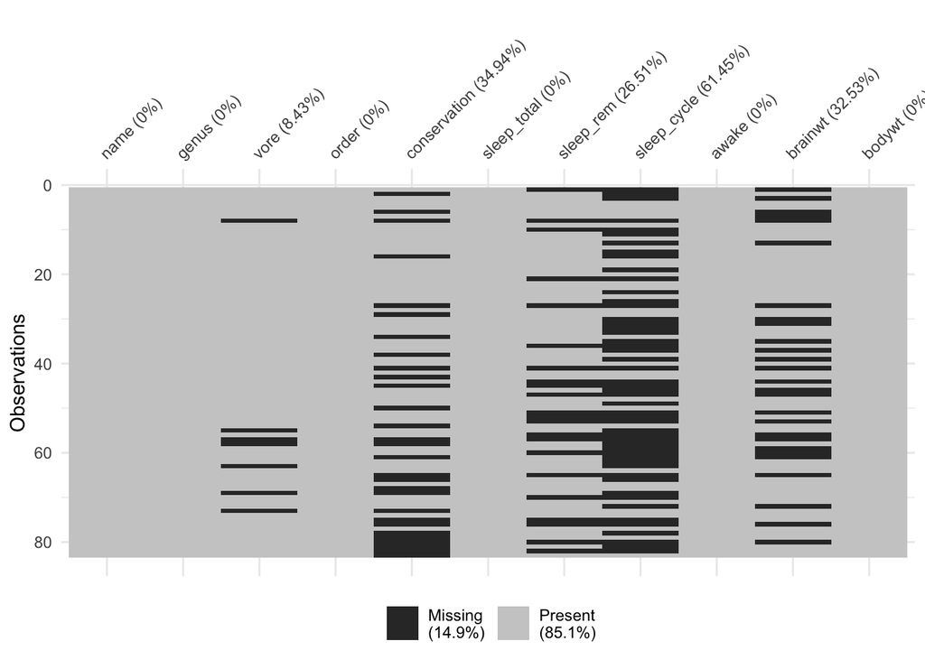

```r
vis_miss(msleep)
```

Comment: It looks like random missing. We can try rearrange by covariate “genus”.

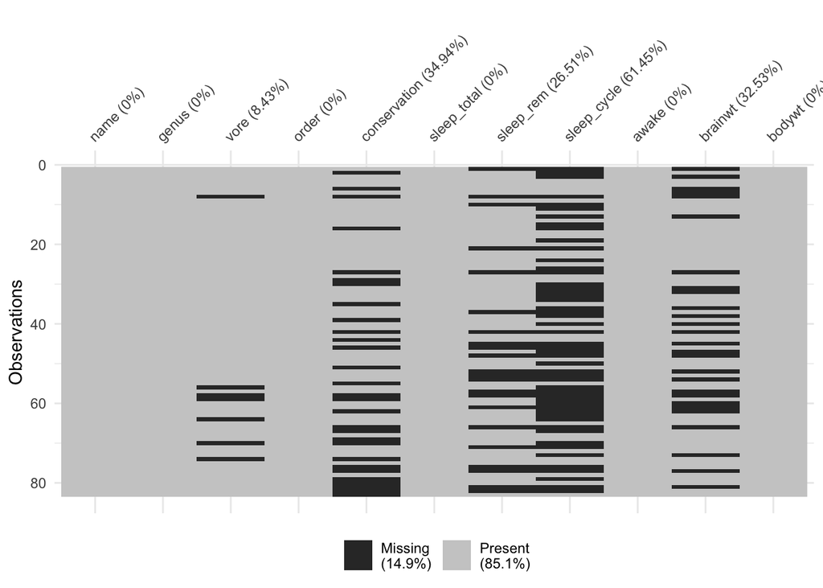

```r
msleep %>% arrange(genus) %>% vis_miss()
```

Comment: Still no obvious pattern.

Visualize any MNAR by turning on “cluster”.

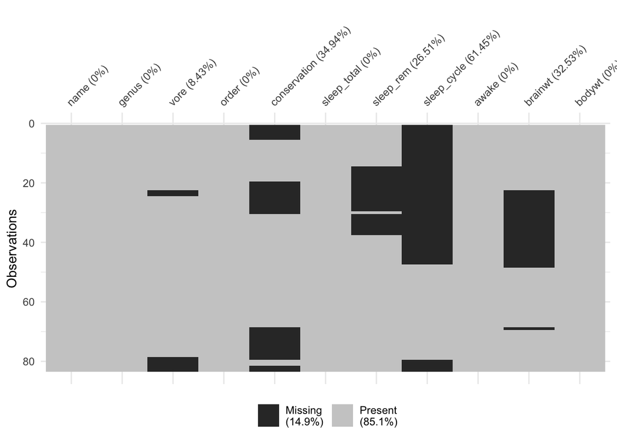

```r
vis_miss(msleep, cluster = TRUE)
```

Summary:

- If the missing is MCAR: None of the variable observed/unobserved will explain the missingness.
- If missing is MAR: some observed variable can explain missingness, meaning you will see cluster of missingness if you arrange the entire dataset by those variables.
- If missing is MNAR: you will see a bisection of dataset by certain variables.